# Comparative Linear Regression Modeling For Ozone Data in MI and in US

Ankita Guha and Kara Marsh

April 22, 2018

Loading the necessary libraries

```r
library(dplyr)
```

```r
library(ggplot2)
library(coefplot)
library(reshape2)
library(scales)
library(boot)
library(e1071)
```

**Data Preparation**

```r
aqAll <- read.table("data/eda_ozone.csv", header = TRUE, sep = ",")
aqAll$X.1 <- aqAll$X <-NULL
aqMI <- read.table("data/mi_ozone.csv", header = TRUE, sep = ",")
aqMI$X.1 <- aqMI$X <- aqMI$exceptional_data_count <- NULL
```

**Partition Data into Training & Test Data Sets for MI**

```r
set.seed(828)
sample_size <- ceiling(0.30 * nrow(aqMI))
testrecs <- sample(nrow(aqMI),sample_size)
MI_test <- aqMI[testrecs,]
MI_train <- aqMI[-testrecs,]  # Negative in front of vector means "not in"
rm(aqMI) # No sense keeping a copy of the entire dataset around
```

**Partition Data into Training & Test Data Sets for US**

```r
set.seed(828)
sample_size <- ceiling(0.30 * nrow(aqAll))
testrecs <- sample(nrow(aqAll),sample_size)
All_test <- aqAll[testrecs,]
All_train <- aqAll[-testrecs,]  # Negative in front of vector means "not in"
rm(aqAll) # No sense keeping a copy of the entire dataset around
```

**MI Prediction Models** Let’s do some basic EDA to get some ideas on the variables that might have some influence over the Model perfomance.

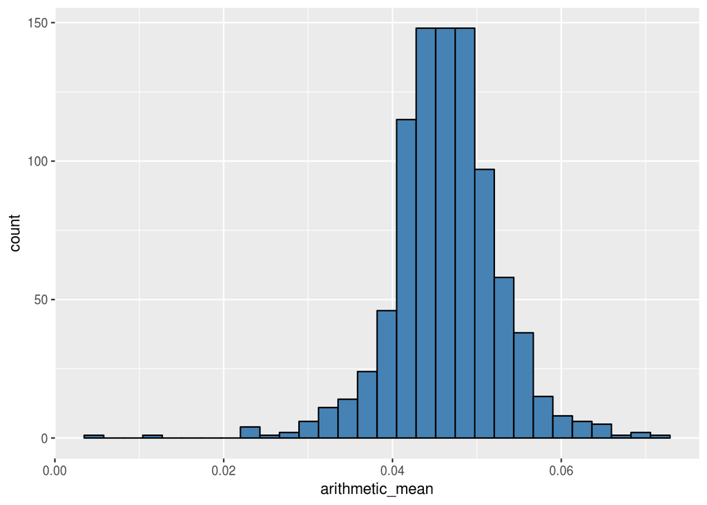

```r
ggplot(data = MI_train) +
  geom_histogram(aes(x = arithmetic_mean),
                 fill = "steelblue",
                 colour="Black")
```

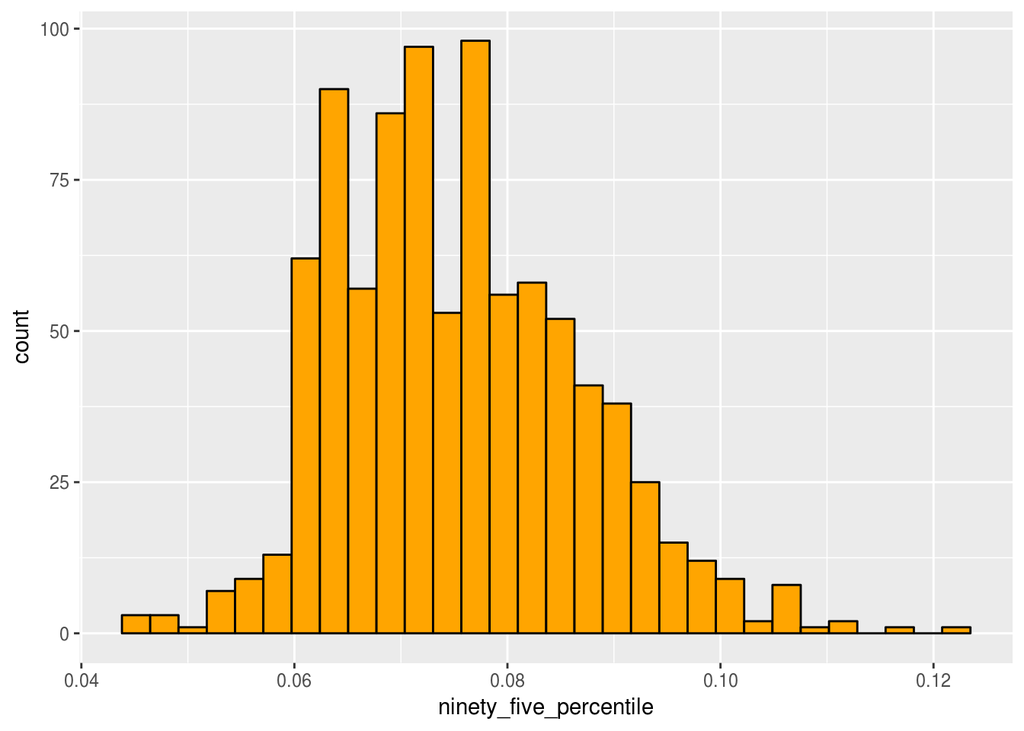

```r
ggplot(data = MI_train) +
  geom_histogram(aes(x = ninety_five_percentile),
                 fill = "orange",
                 colour="Black")
```

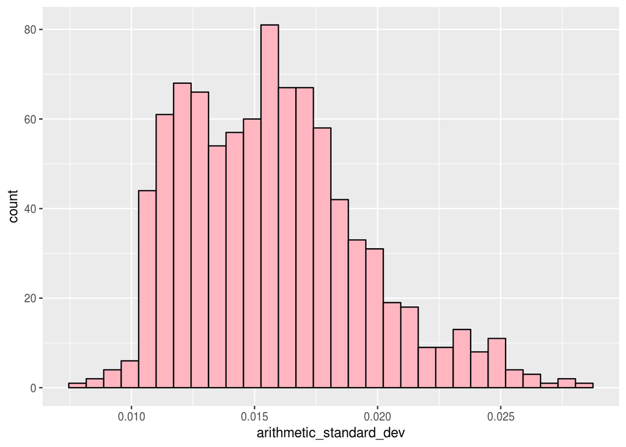

```r
ggplot(data = MI_train) +
  geom_histogram(aes(x = arithmetic_standard_dev),
                 fill = "lightpink",
                 colour="Black")
```

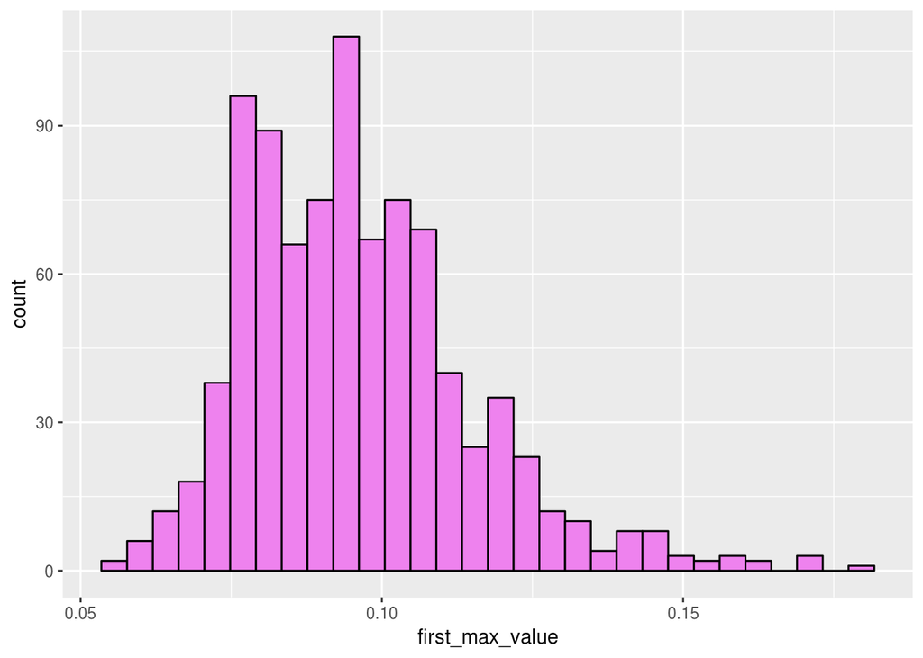

```r
ggplot(data = MI_train) +
  geom_histogram(aes(x = first_max_value),
                 fill = "violet",
                 colour="Black")
```

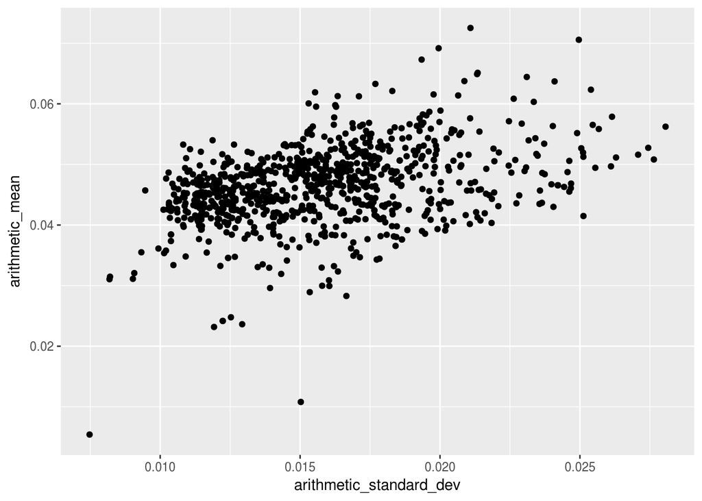

```r
ggplot(data = MI_train) +
  geom_point(aes(y = arithmetic_mean,
                 x = arithmetic_standard_dev))
```

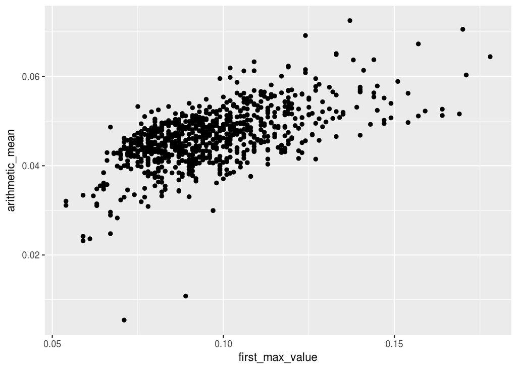

```r
ggplot(data = MI_train) +
  geom_point(aes(y = arithmetic_mean,
                 x = first_max_value))
```

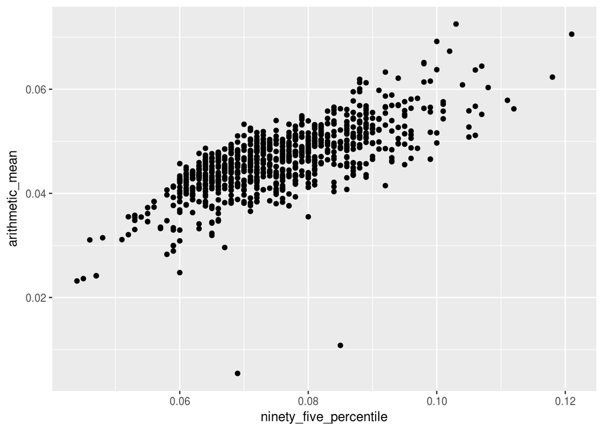

```r
ggplot(data = MI_train) +
  geom_point(aes(y = arithmetic_mean,
                 x = ninety_five_percentile))
```

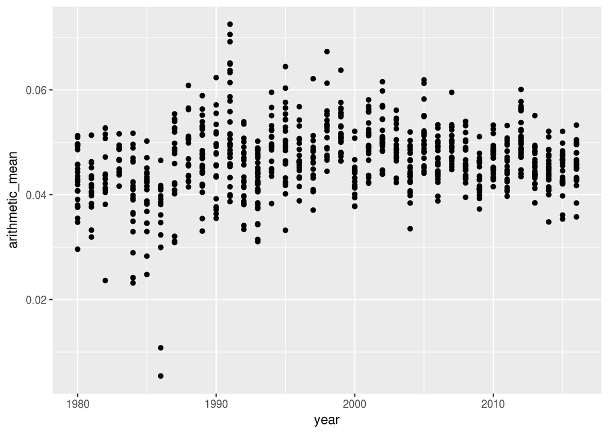

```r
ggplot(data = MI_train) +
  geom_point(aes(y = arithmetic_mean,
                 x = year))
```

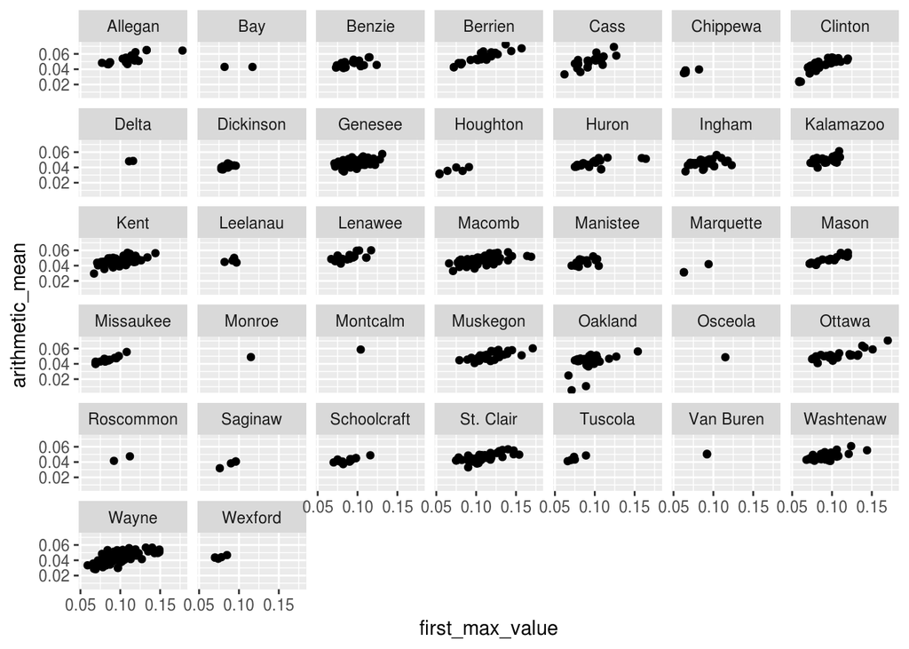

```r
# Scatterplots of arithmetic_mean vs first_max_value faceted along county_name
ggplot(data = MI_train) +
  geom_point(aes(y = arithmetic_mean,
                 x = first_max_value)) +
  facet_wrap(~county_name)
```

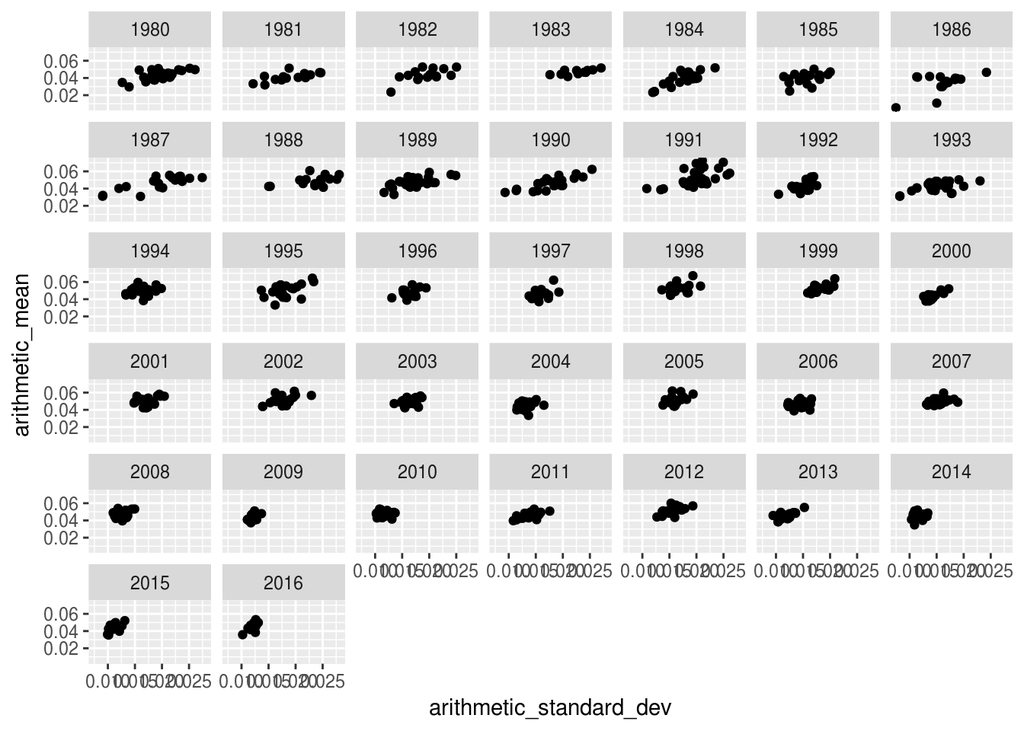

```r
ggplot(data = MI_train) +
  geom_point(aes(y = arithmetic_mean,
                 x = arithmetic_standard_dev)) +
  facet_wrap(~year)
```

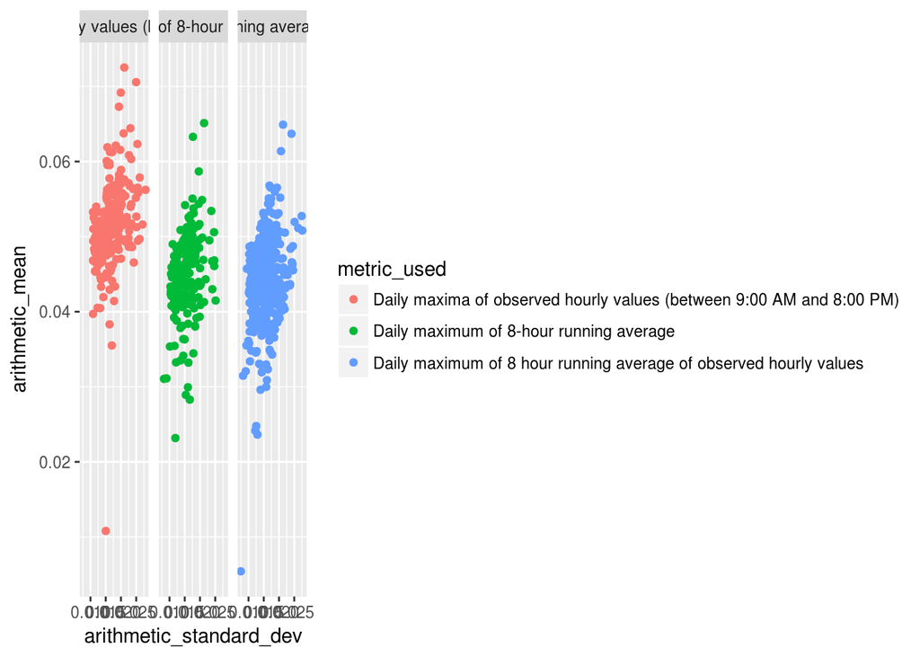

```r
ggplot(data = MI_train) +
  geom_point(aes(y = arithmetic_mean,
                 x = arithmetic_standard_dev,
                 col = metric_used)) +
  facet_wrap(~metric_used)
```

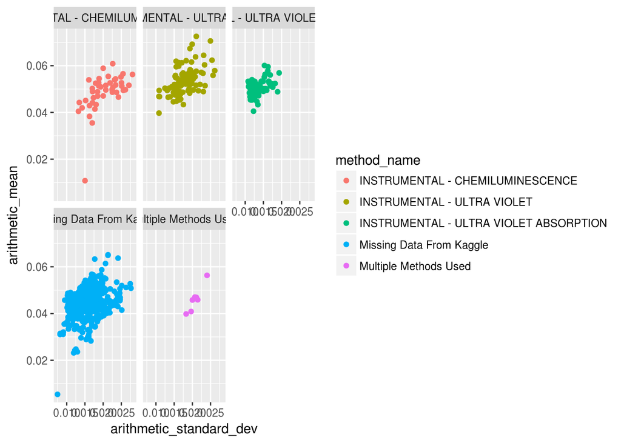

```r
ggplot(data = MI_train) +
  geom_point(aes(y = arithmetic_mean,
                 x = arithmetic_standard_dev,
                 col = method_name)) +
  facet_wrap(~method_name)
```

As we can see from our plots that the “Missing Data From Kaggle” are the main Test or method_name used to capture the paramter_name or the Air Pollutant constituent.

****Linear Regression Model for Ozone Data of MI**** Let’s try to build Linear Regression Model to predict the arithmetic_mean

**Null Model for Comparison with MI Data**

```r
meanMI_lm0 <- lm(arithmetic_mean ~ 1, data = MI_train)
summary(meanMI_lm0)
```

```
##
## Call:
## lm(formula = arithmetic_mean ~ 1, data = MI_train)
##
## Residuals:
##       Min        1Q    Median        3Q       Max
## -0.040913 -0.003535  0.000056  0.003490  0.026188
##
## Coefficients:
##              Estimate Std. Error t value Pr(>|t|)
## (Intercept) 0.0463350  0.0002132   217.3   <2e-16 ***
## ---
## Signif. codes:  0 '***' 0.001 '**' 0.01 '*' 0.05 '.' 0.1 ' ' 1
##
## Residual standard error: 0.006396 on 899 degrees of freedom
```

```r
# Compute the MAD value
median(abs(meanMI_lm0$residuals))
```

```
## [1] 0.003508
```

So we got a pretty low MAD value for the Null Model which is like kind of perfect!

Let’s visualize the Residuals.

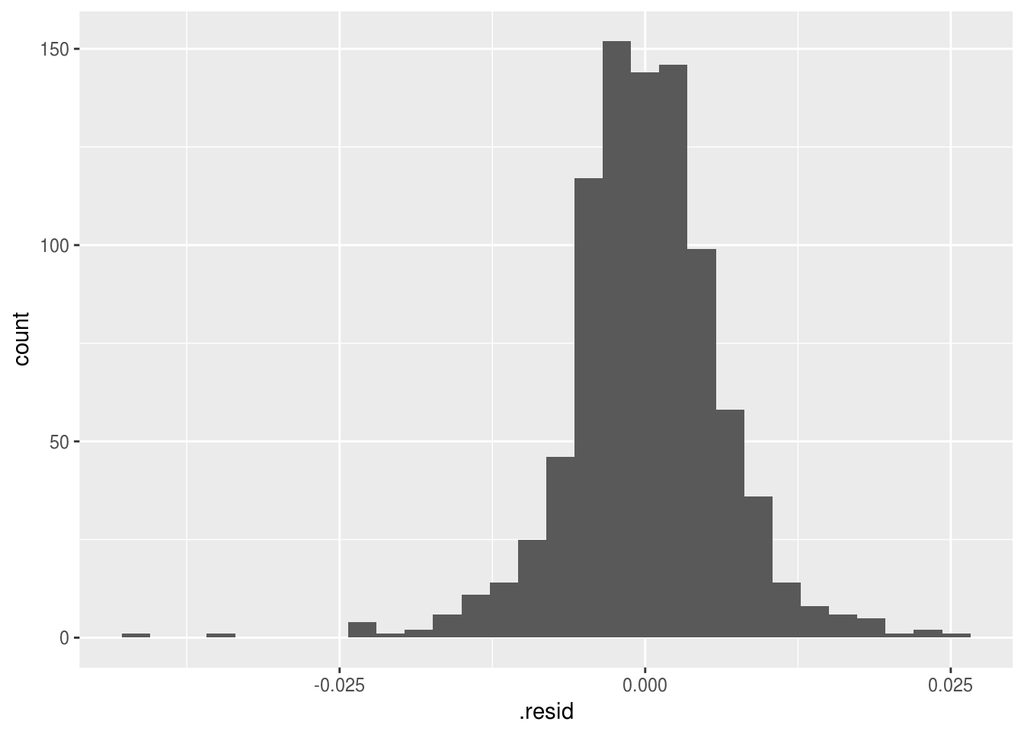

```r
ggplot(meanMI_lm0, aes(x=.resid)) +
  geom_histogram()
```

Prediction at 95% confidence interval

```r
meanMIPredict0 <- predict(meanMI_lm0,
                          newdata=MI_test,
                          se.fit=TRUE,
                          interval="prediction",
                          level=0.95)
```

**MAD Value for Prediction**

```r
df0 <- abs(meanMIPredict0$fit[,1]-MI_test["arithmetic_mean"])

(testMad0 <- median(as.numeric(df0$arithmetic_mean)))
```

```
## [1] 0.003643001
```

```r
head(MI_train)
```

```
##   X.2 parameter_code latitude longitude parameter_name
## 1   1          44201 44.61694 -86.10941          Ozone
## 2   2          44201 43.04722 -83.67016          Ozone
## 4   4          44201 42.19779 -86.30969          Ozone
## 5   5          44201 42.73139 -82.79346          Ozone
## 7   7          44201 42.22862 -83.20820          Ozone
## 9   9          44201 42.29393 -83.71105          Ozone
##           sample_duration
## 1 8-HR RUN AVG BEGIN HOUR
## 2 8-HR RUN AVG BEGIN HOUR
## 4 8-HR RUN AVG BEGIN HOUR
## 5 8-HR RUN AVG BEGIN HOUR
## 7 8-HR RUN AVG BEGIN HOUR
## 9                  1 HOUR
##                                                            metric_used
```

[output cut: 69 more lines]

```r
str(MI_train)
```

```
## 'data.frame':    900 obs. of  36 variables:
##  $ X.2                    : int  1 2 4 5 7 9 10 12 13 14 ...
##  $ parameter_code         : int  44201 44201 44201 44201 44201 44201 44201 44201 44201 44201 ...
##  $ latitude               : num  44.6 43 42.2 42.7 42.2 ...
##  $ longitude              : num  -86.1 -83.7 -86.3 -82.8 -83.2 ...
##  $ parameter_name         : Factor w/ 1 level "Ozone": 1 1 1 1 1 1 1 1 1 1 ...
##  $ sample_duration        : Factor w/ 2 levels "1 HOUR","8-HR RUN AVG BEGIN HOUR": 2 2 2 2 2 1 1 2 2 2 ...
##  $ metric_used            : Factor w/ 3 levels "Daily maxima of observed hourly values (between 9:00 AM and 8:00 PM)",..: 2 3 3 3 3 1 1 2 3 3 ...
##  $ method_name            : Factor w/ 5 levels "INSTRUMENTAL - CHEMILUMINESCENCE",..: 4 4 4 4 4 2 2 4 4 4 ...
##  $ year                   : int  2006 1998 1999 2010 2013 1990 2001 1991 2009 2005 ...
##  $ units_of_measure       : Factor w/ 1 level "Parts per million": 1 1 1 1 1 1 1 1 1 1 ...
##  $ event_type             : Factor w/ 1 level "No Events": 1 1 1 1 1 1 1 1 1 1 ...
##  $ observation_count      : int  3069 4227 3657 4346 8521 5060 4370 3612 4389 4352 ...
##  $ observation_percent    : int  98 96 84 99 98 100 100 99 100 99 ...
##  $ completeness_indicator : Factor w/ 2 levels "N","Y": 2 2 2 2 2 2 2 2 2 2 ...
```

[output cut: 22 more lines]

```r
cor(MI_train$arithmetic_mean, MI_train$arithmetic_standard_dev)
```

```
## [1] 0.3906635
```

```r
cor(MI_train$arithmetic_mean, MI_train$first_max_value)
```

```
## [1] 0.6038165
```

```r
cor(MI_train$arithmetic_mean, MI_train$second_max_value)
```

```
## [1] 0.629176
```

```r
cor(MI_train$arithmetic_mean, MI_train$third_max_value)
```

```
## [1] 0.6476447
```

```r
cor(MI_train$arithmetic_mean, MI_train$fourth_max_value)
```

```
## [1] 0.6738782
```

```r
cor(MI_train$arithmetic_mean, MI_train$ninety_five_percentile)
```

```
## [1] 0.7253514
```

So looks like the arithmetic_mean has a high correlation with the ninety_five_percentile value.

**Correlation Matrix**

```r
correlationbuild1 <- MI_train %>%
  select(county_name,
         first_max_value,
         arithmetic_mean,
         arithmetic_standard_dev,
         ninety_five_percentile)

head(correlationbuild1)
```

```
##   county_name first_max_value arithmetic_mean arithmetic_standard_dev
## 1      Benzie           0.104        0.044050                0.014514
## 2     Genesee           0.105        0.052216                0.015330
## 4     Berrien           0.112        0.056516                0.019346
## 5      Macomb           0.089        0.048398                0.012899
## 7       Wayne           0.078        0.041200                0.010860
## 9   Washtenaw           0.094        0.047766                0.016449
##   ninety_five_percentile
## 1                  0.074
## 2                  0.078
## 4                  0.092
## 5                  0.072
## 7                  0.059
## 9                  0.079
```

```r
cor(correlationbuild1[, c(2, 3:5)])
```

```
##                         first_max_value arithmetic_mean
## first_max_value               1.0000000       0.6038165
## arithmetic_mean               0.6038165       1.0000000
## arithmetic_standard_dev       0.8297376       0.3906635
## ninety_five_percentile        0.8534997       0.7253514
##                         arithmetic_standard_dev ninety_five_percentile
## first_max_value                       0.8297376              0.8534997
## arithmetic_mean                       0.3906635              0.7253514
## arithmetic_standard_dev               1.0000000              0.8575259
## ninety_five_percentile                0.8575259              1.0000000
```

```r
# Putting the Correlation Matrix in a Dataframe
MItraincor <- cor(correlationbuild1[, c(2, 3:5)])

# Melting the Data for ease of plotting
correlationbuild1Melt <- melt(MItraincor,
                              varnames=c("x", "y"),
                              value.name = "Correlation")

# Ordering the Correlation According to their Value
correlationbuild1Melt <- correlationbuild1Melt[order(correlationbuild1Melt$Correlation), ]

# Display the Melted Data
correlationbuild1Melt
```

```
##                          x                       y Correlation
## 7  arithmetic_standard_dev         arithmetic_mean   0.3906635
## 10         arithmetic_mean arithmetic_standard_dev   0.3906635
## 2          arithmetic_mean         first_max_value   0.6038165
## 5          first_max_value         arithmetic_mean   0.6038165
## 8   ninety_five_percentile         arithmetic_mean   0.7253514
## 14         arithmetic_mean  ninety_five_percentile   0.7253514
## 3  arithmetic_standard_dev         first_max_value   0.8297376
## 9          first_max_value arithmetic_standard_dev   0.8297376
## 4   ninety_five_percentile         first_max_value   0.8534997
## 13         first_max_value  ninety_five_percentile   0.8534997
## 12  ninety_five_percentile arithmetic_standard_dev   0.8575259
## 15 arithmetic_standard_dev  ninety_five_percentile   0.8575259
## 1          first_max_value         first_max_value   1.0000000
## 6          arithmetic_mean         arithmetic_mean   1.0000000
## 11 arithmetic_standard_dev arithmetic_standard_dev   1.0000000
## 16  ninety_five_percentile  ninety_five_percentile   1.0000000
```

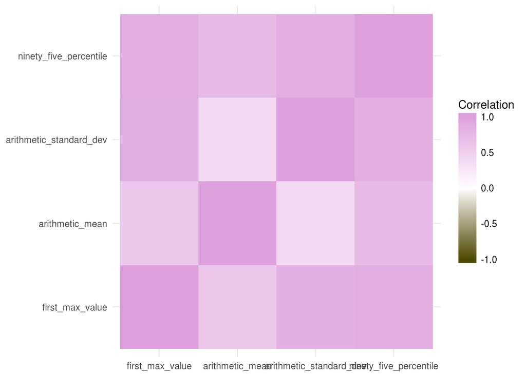

```r
# Heatmap of Correlation For Numerical Predictors
ggplot(correlationbuild1Melt, aes(x=x, y=y)) +
  geom_tile(aes(fill=Correlation)) +
  scale_fill_gradient2(low = muted("yellow"),
                       mid = "white",
                       high = "plum",
                       guide = guide_colorbar(ticks = FALSE,
                                              barheight = 10),
                       limits=c(-1, 1)) +
  theme_minimal() +
  labs(x=NULL, y = NULL)
```

**Model 1**

```r
# Model 1: Build to Understand the effect of the Predictors on the Response Variable
mean1 <- lm(arithmetic_mean ~ method_name + year + observation_count + observation_percent + valid_day_count + required_day_count + arithmetic_standard_dev + first_max_value + second_max_value + third_max_value + fourth_max_value + ninety_nine_percentile + ninety_eight_percentile + ninety_five_percentile + ninety_percentile + seventy_five_percentile + fifty_percentile + ten_percentile + date_of_last_change + norm_mean, data = MI_train)

summary(mean1)
```

```
##
## Call:
## lm(formula = arithmetic_mean ~ method_name + year + observation_count +
##     observation_percent + valid_day_count + required_day_count +
##     arithmetic_standard_dev + first_max_value + second_max_value +
##     third_max_value + fourth_max_value + ninety_nine_percentile +
##     ninety_eight_percentile + ninety_five_percentile + ninety_percentile +
##     seventy_five_percentile + fifty_percentile + ten_percentile +
##     date_of_last_change + norm_mean, data = MI_train)
##
## Residuals:
##        Min         1Q     Median         3Q        Max
## -2.529e-16 -3.216e-17  0.000e+00  3.245e-17  2.611e-16
##
## Coefficients:
##                                                     Estimate Std. Error
## (Intercept)                                       -7.215e-15  5.686e-15
## method_nameINSTRUMENTAL - ULTRA VIOLET            -2.399e-17  1.949e-17
## method_nameINSTRUMENTAL - ULTRA VIOLET ABSORPTION  1.801e-17  2.087e-17
## method_nameMissing Data From Kaggle               -7.416e-18  1.748e-17
## method_nameMultiple Methods Used                   2.751e-17  3.914e-17
## year                                               3.536e-18  2.810e-18
## observation_count                                  7.573e-21  4.114e-21
## observation_percent                                3.055e-19  3.449e-18
## valid_day_count                                   -2.925e-19  1.756e-18
## required_day_count                                 3.624e-19  1.542e-18
## arithmetic_standard_dev                            1.792e-15  5.041e-15
## first_max_value                                    1.281e-15  5.024e-16
## second_max_value                                  -1.082e-15  1.358e-15
## third_max_value                                    1.017e-15  1.375e-15
## fourth_max_value                                  -8.330e-16  1.995e-15
## ninety_nine_percentile                            -1.045e-15  1.306e-15
## ninety_eight_percentile                            4.315e-16  1.826e-15
## ninety_five_percentile                            -8.711e-16  1.565e-15
## ninety_percentile                                  1.796e-15  1.819e-15
## seventy_five_percentile                           -3.719e-15  2.050e-15
## fifty_percentile                                   5.703e-15  2.311e-15
## ten_percentile                                    -2.317e-15  1.632e-15
## date_of_last_change2016-08-02                      1.661e-18  2.325e-17
## date_of_last_change2016-08-03                      3.222e-17  3.402e-17
```

[output cut: 52 more lines]

```
## date_of_last_change2016-08-18                      8.540e-01  0.39316
## date_of_last_change2016-12-06                     -6.410e-01  0.52177
## date_of_last_change2016-12-21                      7.530e-01  0.45195
## date_of_last_change2017-01-19                      5.760e-01  0.56468
## date_of_last_change2017-02-24                     -4.900e-01  0.62402
## date_of_last_change2017-03-21                      9.730e-01  0.33092
## date_of_last_change2017-03-28                     -3.640e-01  0.71601
## date_of_last_change2017-04-25                     -1.545e+00  0.12273
## norm_mean                                          4.917e+14  < 2e-16 ***
## ---
## Signif. codes:  0 '***' 0.001 '**' 0.01 '*' 0.05 '.' 0.1 ' ' 1
##
## Residual standard error: 9.325e-17 on 858 degrees of freedom
## Multiple R-squared:      1,  Adjusted R-squared:      1
## F-statistic: 1.032e+29 on 41 and 858 DF,  p-value: < 2.2e-16
```

Okay, so looks like our data is really Normalized as we have a R-Square of exactly 1 with a significant low p value.

```r
# Compute the MAD value
median(abs(mean1$residuals))
```

```
## [1] 3.231402e-17
```

```r
mean1$coefficients
```

```
##                                       (Intercept)
##                                     -7.214697e-15
##            method_nameINSTRUMENTAL - ULTRA VIOLET
##                                     -2.399298e-17
## method_nameINSTRUMENTAL - ULTRA VIOLET ABSORPTION
##                                      1.800514e-17
##               method_nameMissing Data From Kaggle
##                                     -7.415951e-18
##                  method_nameMultiple Methods Used
##                                      2.750827e-17
##                                              year
##                                      3.536165e-18
##                                 observation_count
##                                      7.572518e-21
##                               observation_percent
##                                      3.055404e-19
##                                   valid_day_count
##                                     -2.924808e-19
##                                required_day_count
##                                      3.624377e-19
##                           arithmetic_standard_dev
##                                      1.791923e-15
##                                   first_max_value
##                                      1.280864e-15
##                                  second_max_value
##                                     -1.081885e-15
##                                   third_max_value
##                                      1.016898e-15
##                                  fourth_max_value
##                                     -8.330156e-16
##                            ninety_nine_percentile
##                                     -1.045207e-15
##                           ninety_eight_percentile
##                                      4.314794e-16
##                            ninety_five_percentile
##                                     -8.710921e-16
##                                 ninety_percentile
##                                      1.795550e-15
##                           seventy_five_percentile
##                                     -3.718529e-15
```

[output cut: 29 more lines]

```
##                                     -3.596498e-17
##                     date_of_last_change2016-12-21
##                                      1.807216e-17
##                     date_of_last_change2017-01-19
##                                      5.458506e-17
##                     date_of_last_change2017-02-24
##                                     -4.660136e-17
##                     date_of_last_change2017-03-21
##                                      6.578686e-17
##                     date_of_last_change2017-03-28
##                                     -2.048854e-17
##                     date_of_last_change2017-04-25
##                                     -8.726518e-17
##                                         norm_mean
##                                      4.664183e-02
```

Let’s try to visualize the Model

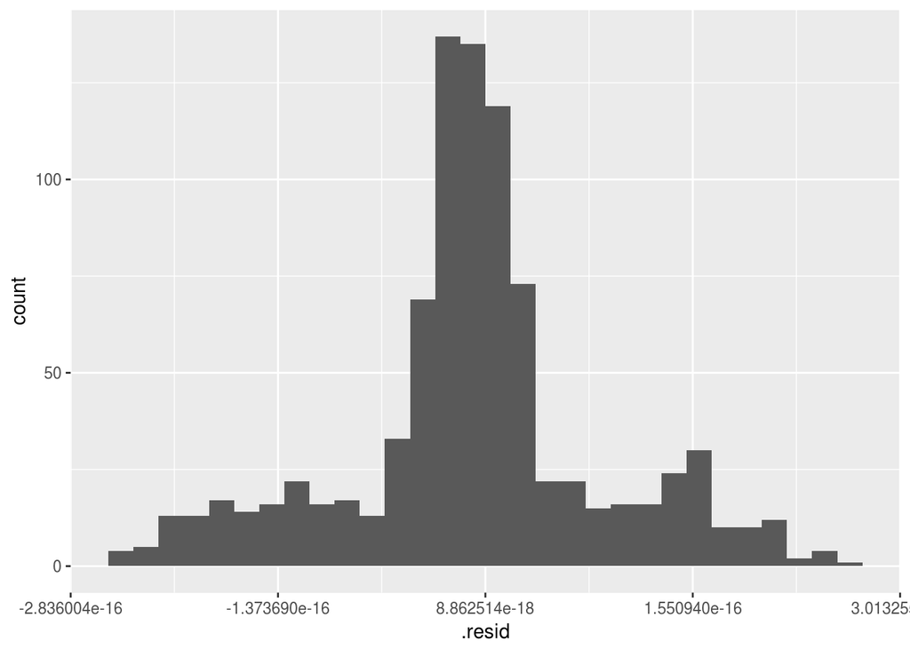

```r
ggplot(mean1, aes(x=.resid)) + geom_histogram()
```

From the Residual Analysis, we considered to check our homeskedasticity of Variance along two of the most significant Predictors that is the method_name and norm_mean. Ideally we would like to see random scatter in our Residual Analysis, but for both the plot we can see that the Residuals are not scatttered randomly but accumulated over a certain point, forming a Hat like pattern indicating that the variance in the residuals is not constant.

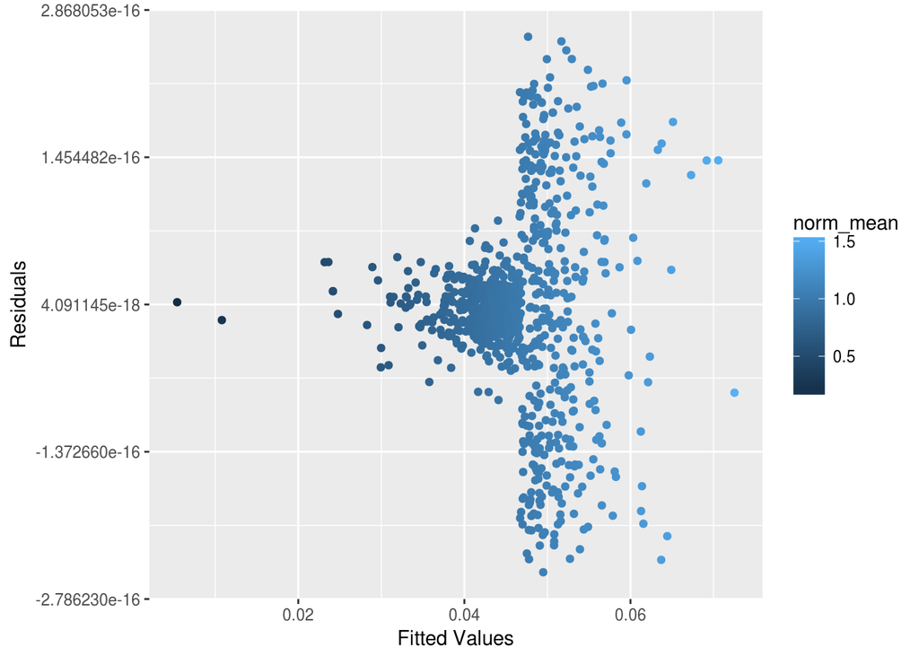

```r
# Residual Analysis by norm_mean
ggplot(data=mean1, aes(x=.fitted, y = .resid)) +
  geom_point(aes(color=norm_mean)) +
  labs(x="Fitted Values", y="Residuals")
```

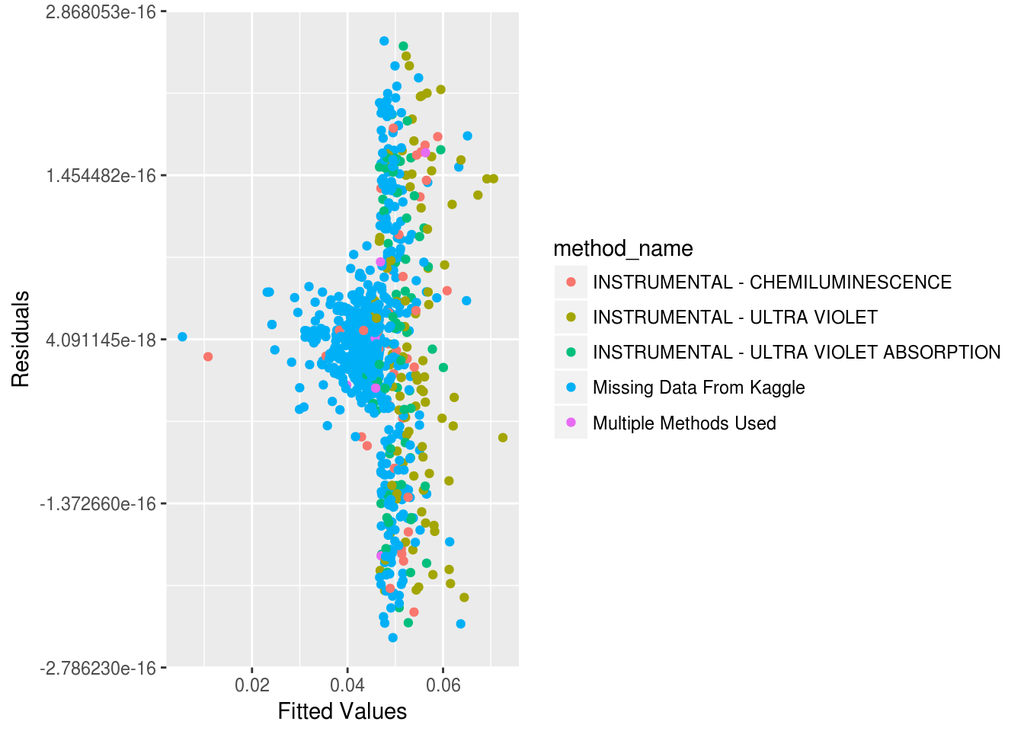

```r
# Residual Analysis by method_name
ggplot(data=mean1,
       aes(x=.fitted, y = .resid)) +
  geom_point(aes(color=method_name)) +
  labs(x="Fitted Values", y="Residuals")
```

The Residuals also seemed to have the major influence from the unknown Test method_name which was initially blank and we renamed it as “Missing Data From Kaggle”

```r
# Making Prediction with Test Data at 95% Confidence Interval
meanMIPredict1 <- predict(mean1, newdata=MI_test, se.fit=TRUE,
                         interval="prediction", level=0.95)
```

**MAD Value for Prediction**

```r
df1 <- abs(meanMIPredict1$fit[,1]-MI_test["arithmetic_mean"])

(testMad1 <- median(as.numeric(df1$arithmetic_mean)))
```

```
## [1] 3.469447e-17
```

Looking at our p, value from the Anova Test, looks like we have a very good Fit Model!

```r
anova(mean1)
```

```
## Analysis of Variance Table
##
## Response: arithmetic_mean
##                          Df    Sum Sq   Mean Sq    F value    Pr(>F)
## method_name               4 0.0088295 0.0022074 2.5384e+29 < 2.2e-16 ***
## year                      1 0.0008763 0.0008763 1.0077e+29 < 2.2e-16 ***
## observation_count         1 0.0002695 0.0002695 3.0994e+28 < 2.2e-16 ***
## observation_percent       1 0.0013975 0.0013975 1.6071e+29 < 2.2e-16 ***
## valid_day_count           1 0.0000000 0.0000000 3.5845e+24 < 2.2e-16 ***
## required_day_count        1 0.0000168 0.0000168 1.9334e+27 < 2.2e-16 ***
## arithmetic_standard_dev   1 0.0082911 0.0082911 9.5343e+29 < 2.2e-16 ***
## first_max_value           1 0.0027481 0.0027481 3.1602e+29 < 2.2e-16 ***
## second_max_value          1 0.0012434 0.0012434 1.4299e+29 < 2.2e-16 ***
## third_max_value           1 0.0010236 0.0010236 1.1770e+29 < 2.2e-16 ***
## fourth_max_value          1 0.0012758 0.0012758 1.4671e+29 < 2.2e-16 ***
## ninety_nine_percentile    1 0.0000323 0.0000323 3.7129e+27 < 2.2e-16 ***
## ninety_eight_percentile   1 0.0004869 0.0004869 5.5990e+28 < 2.2e-16 ***
## ninety_five_percentile    1 0.0028813 0.0028813 3.3133e+29 < 2.2e-16 ***
## ninety_percentile         1 0.0020006 0.0020006 2.3006e+29 < 2.2e-16 ***
## seventy_five_percentile   1 0.0022713 0.0022713 2.6119e+29 < 2.2e-16 ***
## fifty_percentile          1 0.0008530 0.0008530 9.8087e+28 < 2.2e-16 ***
## ten_percentile            1 0.0001292 0.0001292 1.4861e+28 < 2.2e-16 ***
## date_of_last_change      19 0.0000504 0.0000027 3.0489e+26 < 2.2e-16 ***
## norm_mean                 1 0.0021028 0.0021028 2.4181e+29 < 2.2e-16 ***
## Residuals               858 0.0000000 0.0000000
## ---
## Signif. codes:  0 '***' 0.001 '**' 0.01 '*' 0.05 '.' 0.1 ' ' 1
```

Our data looks almost like normally distributed. The normal distribution has skew and kurtosis values of zero. It is a measure of data symmetry. As a rule, negative skewness indicates that the mean of the data values is less than the median, and the data distribution is left-skewed. Kurtosis describes the tail shape of the data distribution. The Positive value as seen from our Kurtosis indicates that our data has a fat tailed data distribution.

```r
skewness(mean1$residuals)
```

```
## [1] -0.01824071
```

```r
kurtosis(mean1$residuals)
```

```
## [1] 0.6263941
```

Let’s clean up some of our memory space for next iteration of analysis.

```r
rm(MI_test, MI_train, df1, MItraincor,
   correlationbuild1, correlationbuild1Melt,
   mean1, meanMI_lm0, meanMIPredict1)
```

**Fidings on MI Data Prediction**

- Our Model is significant with an accurate R Squared Value of 1! (Rare Case No Doubt!).
- The Null Model which we considered as the base for comparison has a very high performance value. So, we had to be cautious while building other Models. But we still went ahead to play with some of the variables until we get a Model which we thought would make a good fit to be here. After diligently considering some of the Model performance we considered this Model as our best Model as compared to our Null Model.
- MAD Value for Train: 3.231402e-17 MAD Value for Test: 3.469447e-17, representing signs of very little Overfit! Otherwise perfectly Fit Model even as seen from the Anova Test.
- But overall Model performance was good mainly due to the data that we choose to build and Predict the Model.
- It definitely has a lot of scope to do a lot more study with this dataframe. But due to our limited Project Scope, we would have to restrict ourselves here.

**US Prediction**

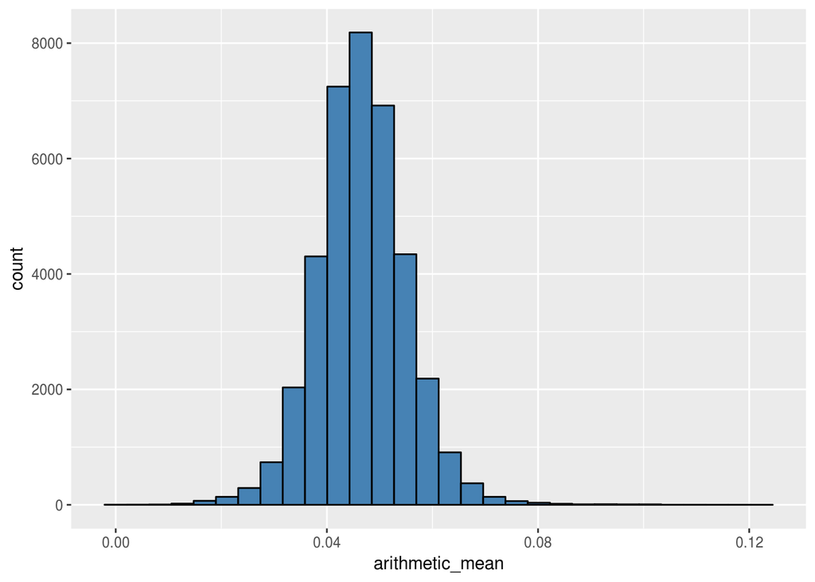

```r
ggplot(data = All_train) +
  geom_histogram(aes(x = arithmetic_mean),
                 fill = "steelblue",
                 colour="Black")
```

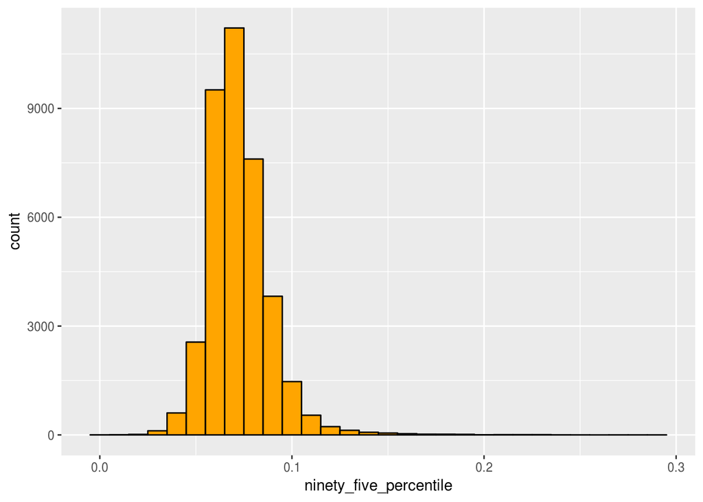

```r
ggplot(data = All_train) +
  geom_histogram(aes(x = ninety_five_percentile),
                 fill = "orange", colour="Black")
```

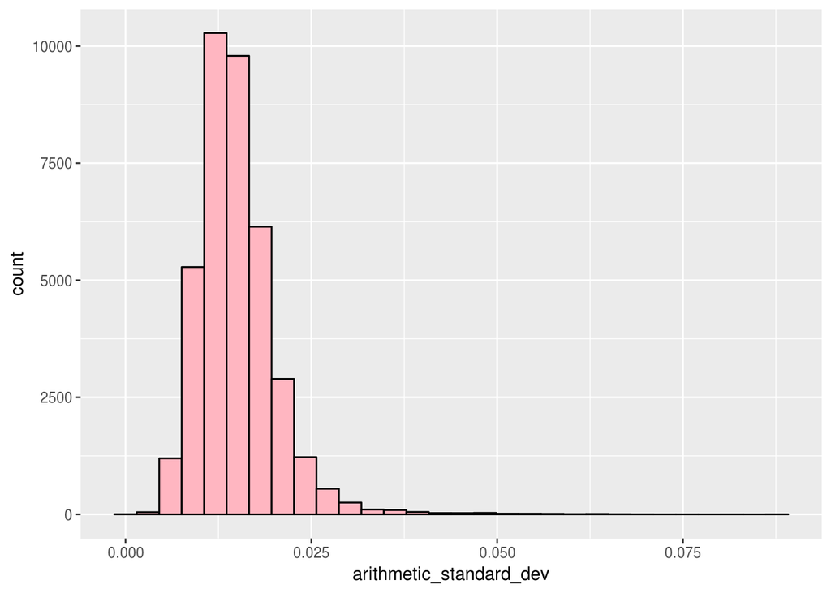

```r
ggplot(data = All_train) +
  geom_histogram(aes(x = arithmetic_standard_dev),
                 fill = "lightpink", colour="Black")
```

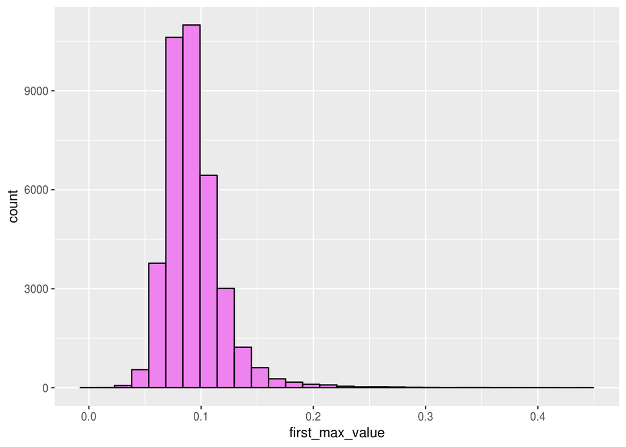

```r
ggplot(data = All_train) +
  geom_histogram(aes(x = first_max_value),
                 fill = "violet",
                 colour="Black")
```

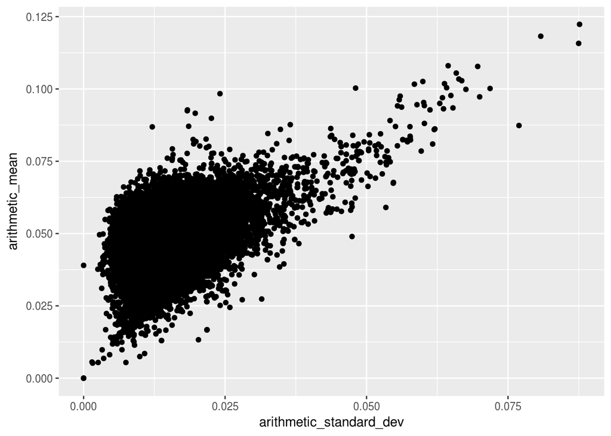

```r
ggplot(data = All_train) +
  geom_point(aes(y = arithmetic_mean,
                 x = arithmetic_standard_dev))
```

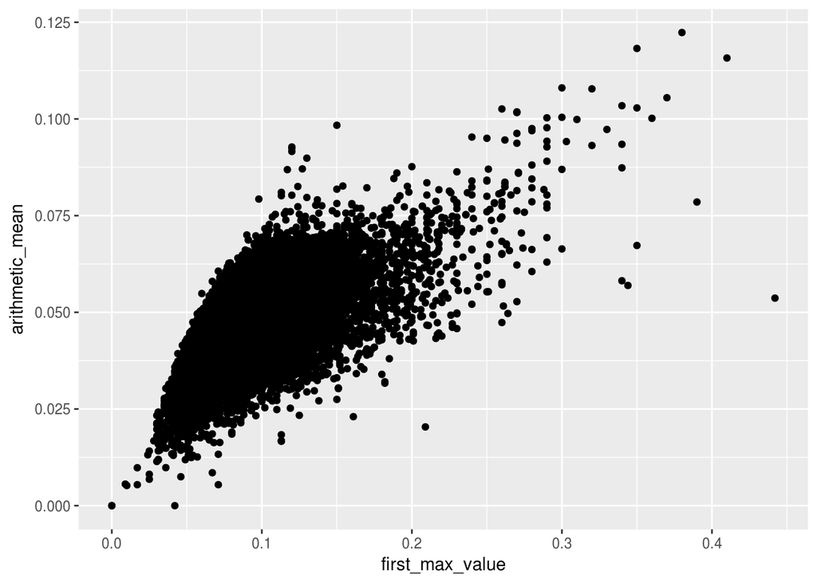

```r
ggplot(data = All_train) +
  geom_point(aes(y = arithmetic_mean,
                 x = first_max_value))
```

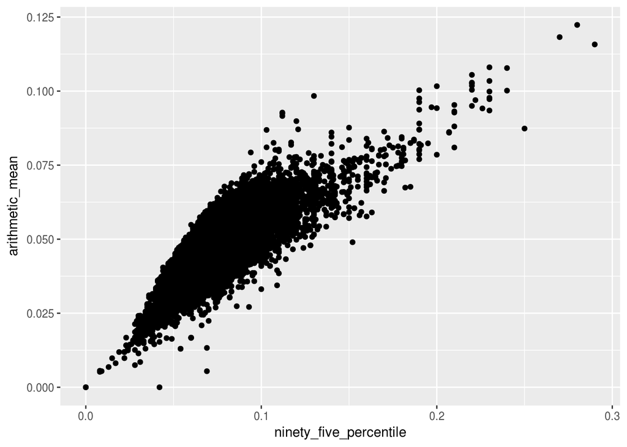

```r
ggplot(data = All_train) +
  geom_point(aes(y = arithmetic_mean,
                 x = ninety_five_percentile))
```

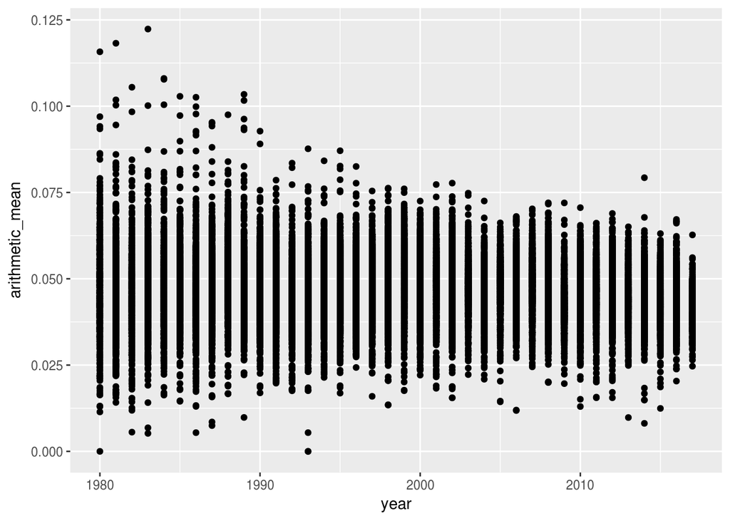

```r
ggplot(data = All_train) +
  geom_point(aes(y = arithmetic_mean,
                 x = year))
```